# Discover 2015: dopad a celkové hodnocení

*Zpět na rozcestník zpětné vazby*

# Ovlivnili jsme účastníky?

## Plány do budoucna

### Ovlivnila účast na Discover tvoje plány do budoucna?

Podle turnusu, pohlaví, země - žádné velké rozdíly

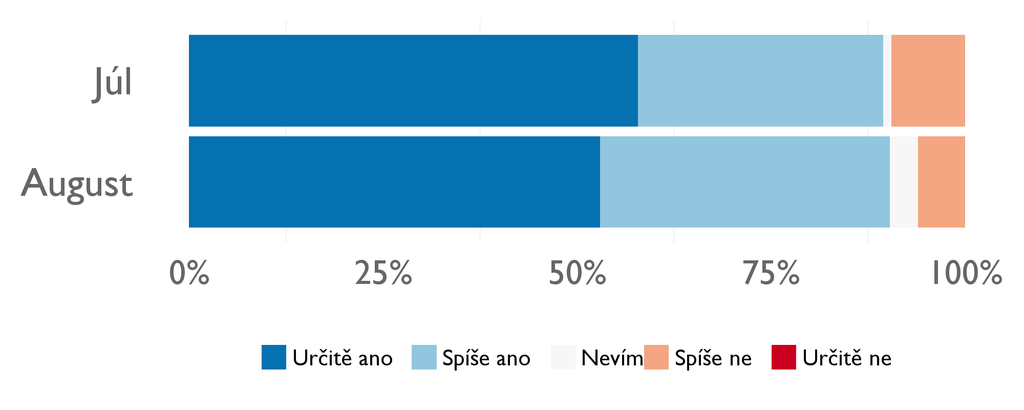

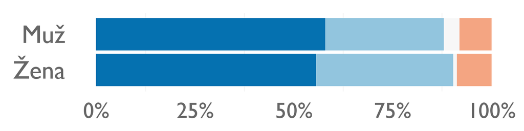

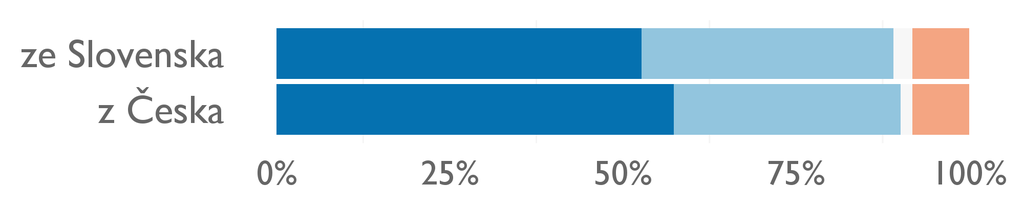

Podle věku - efekt maturantů

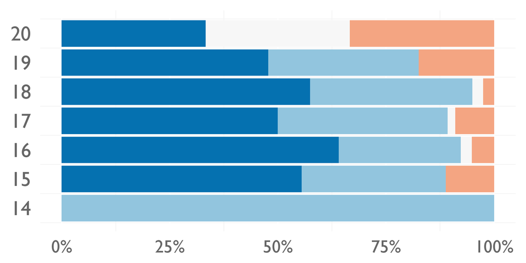

### Jak?

- Discover mi otevřel cestu do světa a ukázal mi spoustu možností, jak studovat kvalitněji třeba i v Čechách. Discover mě rozhodně podpořil v hlášení se na nejlepší školy světa a tím mi dal šanci tam studovat, protože jinak bych to ani nezkusil.
- Síce som vedela čo chcem študovať, nevedela som kde a aké školy sú vhodné na to čo chcem študovať. Tým, že som sa o tom rozprávala s lektormi odporučili mi veľa užitočných vecí aj napr. kde ísť študovať a ako sa na to pripraviť.
- Už viem aká náročná je práca lekára a preto musím k tomuto rozhodnutiu pristupovať zodpovedne. Stále chcem byť lekárkou aj keď viem, že obeta pre druhých bude vysoká.
- ovplyvnilo to tak že som si uvedomila niektoré veci napríklad ak chcem študovat medicínu v nemecku musím mat uroven C1 nemčiny…to mi povedali ostatný
- Rozšírila som si obzory a zistila čomu sa možem v budúcnosti venovať. Bola to úžasná skúsenosť, ktorú si ešte určite zopakujem.
- začala jsem uvažovat o studiu práva
- Dozvedel som sa o nových možnostiach a príležitostiach z roznych oblastí, od vysokoškolského štúdia až po cestovanie.
- Objevil jsem zde spoustu nových zálib a začal jsem se dívat na svět novým pohledem.
- Ukazala mi okrem ineho to, ze mozem robit co by som chcela a ist studovat do USA
- Víc si věrím, co se týce výberu skol v zahranicí a mám mnohem větší motivaci do budoucna.
- Discover me motivoval prihlasit se na univerzitu v USA
- Ukázala mi nové možnosti a v niektorých smeroch aj uľahčila cestu ktorá ma čaká informáciami ktoré sa ku mne dostali.
- Výtvarný kurz ma utvrdil v tom, že si dám prihlášku aj na dizajn.
- Definitivně jsem se rozhodl hlásit se na zahraniční university, na které bych se jinak nehlásil.
- Kompletně jsem změnila postoj co se týče škol. Discover byl k budoucímu studiu velmi přínosný. Mám o mnoho více informací ke studiu ve VB i ke svému oboru.
- Dozvedela som sa o vela novych moznostiach co sa ci uz studia, mimoskolskych aktivit alebo dobrovolnictva tyka. Taktiez, kurzy na ktore som chodila mi pomohli definitivne sa rozhodnut co studovat na vyske.
- Veľmi ma to motivovalo vo viacerych smeroch.
- Zistila som, čo by ma bavilo robiť v budúcnosti, ktoré odbory sa oplatia študovať a aké profesie môžem z nich vykonávať. Taktiež som sa naučila niečo o výberovom konaní na školách v ČR a UK
- Pretože už mám aspoň o kúsok viac ucelenú predstavu, čo môžem v budúcnosti robiť. To sa týka najmä štúdia na univerzite - vďaka napríklad workshopu o štúdiu práva - ale aj o potenciálnom zamestnaní - viem, že chcem stážovať, o čom som pred Discoverom neuvažoval, alebo tiež skúsiť prácu v neziskovke.
- Priblizilo mi to moznosti v obore, ktorym som si predtym nebola ista.
- Igi ma pravdepodobne presvedcil svojim kurzom na studium prava!!!
- Začala som uvažovať o štúdiu v zahraničí, dobrovoľnictve a iných záujmových činnostiach.
- Myslím si, že som viac odhodlaná samostatne sa vzdelávať, podieľať sa na dobrovoľníckych aktivitách a začať uvažovať nad svojou budúcnosťou.
- Tým že mi predstavil kopec nových názorov. A tak mám teraz väčší prehľad o mojich možnostiach.
- Nejvíce asi v rámci otázky ohledně neziskových organizací a dobrovolnictví, ale samozřejmě i v rámci výběru vysokých škol aneb mi toto celé seskupení lektorů ukázalo, že i normální člověk s dobrým doporučením a snahou něco dělat se může dostat na prestižní školy v Anglii apod. Takže teďka více věřím svým možnostem a rozhodně se chystám už teraz se zapojit do aktivního dobrovolničení, které (skrytě doufám) povede později k cestě za hranice ČR i Evropy.
- Síce úplne neovplyvnila to, čo chcem študovať, ovplyvnila ma v pozeraní sa na svet a inšpirovala ma byť aktívnejšou, pomáhať tam, kde môžem. Zároven ma inšpirovala aj ku konkrétnym aktivitám, keď prídem domov hned sa chystám urobiť prieskum o dobrovolníctve.
- Rozhodne ma inšpirovala byť aktívnejšia a skúšať moje talenty využívať naplno.
- Zistil som co chcem studovat
- Zvažuji podat prihlášku na UWC.
- Rada by som debatovala v SDA.
- Na vysokej si budem hladať stáž.
- Motivovalo mě to k tomu, hledat různé možnosti stipendií do zahraničí a jiných zajímavých věcí o kterých jsem dosud neměla tusení. A bohužel mě mrzí, že jsem nevěděla o nějakých možnostech studia např. v Anglii na střední škole.
- Dozvedela som sa o nových možnostiach, ktoré sa určite budem snažiť využiť
- Vo velkej miere, vyvrátili sa mi mýty o niektorých prácach a zároveň sa mi otvoril nový svet možností.
- Dozvěděl jsem se o desítkách možností, co v budoucnu dělat.
- Uvazujem nas studiom v UK.
- Akadémia Discover mi dala vela. Spoznala som ludí, ktorí sú ako ja. Zaujíma ich svet okolo, sú prístupný, milý a otvorený. To čo som tu zažila sa nedá s ničím porovnat. A ten pocit, že možem len tak oslovit niekoho pri ceste do jedálne a začat sa s nim rozprávat o budúcnosti alebo o inej téme, čo ma zaujíma, je to čo robí Discover jedinečným. A to je úžastné. Odnášam si skúsenosti a chut robit veci lepšími. Tento nový pohlad na vec mi určite ešte prevráti moje budúce plány.
- Studium v zahraničí, stáže, motivace.
- Setkání s mnoha inspirativními lidmi a skvělý program je nemohli neovlivnit. Taky jsem se dozvěděl, že i když jsem dokonalej polobůh, chci-li něčeho dosáhnout, budu na tom muset pracovat.
- Disccover mi ukázal moje slabé miesta a teda čo možem zlepšovat.
- Pomohla mi ujasnit si, jakou vysokou školu bych chtěl absolvovat a rozšířila mi obzory, zejména v otázce mnoha netradičních oborů a možností, které na středí škole mám (stipendia, debatování…)
- Doyvedela som sa akym sposobom sa mozem vo volnom case rozvijat co jednoznacne ovplyvni moju budnucnost. Takisto som ziskala informacie o mnohych studijnych odboroch a prehodnotila svoje doterajsie volby UNI.
- Ukazal mi ze kurz na ktery jsem chodila me bavi a urcite budu zvazovat jit timto smerem
- Discover ovlivnil moje rozhodnuti ohledne vysokoskolskeho studia v zahranici.
- Presvedila som sa o tom ze chcem ist studovať do USA a zaroven si myslim ze po discover budem este viacej uvazovať o studiu prava
- Urcite ma to motivovalo a inspirovalo a uistilo v tom, ze po strednej chcem ist studovat do zahranicia na vysku.
- rozsiril moju perspektivu a zvacsil moznosti o tom co mozem robit a dozvedela som sa o vela novych veciach ktore mozem aj vo svojom veku ovplyvnit.
- Naucil som sa ake mam moznosti v zahranici ale aj doma
- zistila som, ktore discipliny by ma bavili studovat a ktore naopak nie, ktore mi ako sedia (aspon na prvy pohlad). skvela skusenost
- Dozvedela som sa mnoho užitočných informácií o štúdiu v Anglicku, o tom, že všetko sa dá dosiahnuť.
- Rozhodne. Ľudia na Discoveri mi ukázali ako efektívne (a vôbec) robiť to, čo chcem, som nevedela ako sa k tomu dostať, kde presne hľadať potrebné informácie, etc. Taktiež mi ukázali, že dostať sa na školy a študovať odbor ešte neznamená, že nemôžem robiť/študovať niečo úplne iné, čo tiež dosť ovplyvnilo stres z výšky. Ďakujem. :)
- Teraz mam aspon aky taky plan ako sa konkretnu skolu dostat predtym som nevedela ako. Mala som malo informácii.
- Dala mi plno nových možností do budoucna a teď už vím, co bych chtěla zhruba studovat. Pravděpodobně také zkusím získat stipendium a přihlásit se na nějakou střední školu v zahraničí.
- Rozhodl jsem se, jakou bych chtel mit praci v budoucnu a jaka je možná cesta.
- Výběr vysoké školy, spousta zajímavých aktivit, které je možno dělat, o kterých jsem předtím nepřemýšlel
- Ujistila jsem se v tom, co chci dělat!
- Discoverbol pre mna neskutocne dobra skusenost. Za tento jeden uzastny tyzden som spoznala velke mnozstvo uzastnych ludi tak ako ucastnikov aj erfektnzch lektorov. Dodali mi velku davku sebodovery v to co mozem urobit do buducna a vela uzitocnych informacii o tom ako to vo svete realne chodi.
- Budem sa snažiť byť viac aktívna, takisto som prišla na to, že naozaj chcem robiť niečo s medicínou.
- Myslím si, že účast na discoveru mé plány do budoucna ovlivnila hodně a to proto, že mi nabídla na plno věcí úplně nový pohled a seznámila mě s řadou možností, jak se dál rozvíjet a využîvat čas, od všemožných dobrovolnický aktivit, po možnosti studia v zahraničí atd.
- Na Discover jsem jel s ucelem vymezit si sve cile pro sve budouci studium. Tim padem Discover ovlivnil moje plany, i kdyz ne tak jak jsem predpokladal. Discover mi poskytl nekolik ruznych nazoru a kritickych pohledu, diky kterým musim v nadchazejicich tydnech prehodnotit sve preference, co se tyce mych budoucich studii.
- Už som ich mal predtým pomerne premyslené; Discover ma len utvrdil v tom, že o takúto prácu mám záujem
- Budem sa zamýšľať nad vecami, nad ktorými som sa doteraz nezamýšľala. Ujasnila som si veci v tom, čo by ma bavilo a čo nie.
- Discover mi ukázal, že nič v oblasti vzdelávania nie je nemožné. Dostaneme sa na akúkoľvek školu chceme, stačí si za tým zamakať.
- Poznala jsem mnoho nových možností a také, že žádné dveře se neotevřou samy
- Potkala jsem zu hodně mladých úspěšných lidí a ráda bych byla za 10 let na jehicj místě.
- Discover mi poukázal na nové možnosti uplatnenia sa v budúcnosti a kurzy s témami, o ktoré som sa predtým nezaujímala, ma presvedčili, že nie som zameraná iba na tie odbory, ktorým som sa predtým venovala.
- utvrdil ma v činnostiach, kt. robím a v tom, čo chcem ísť študovať. Ovplyvnil však moje premýšľanie o mieste štúdia.
- Workshopy, rady a povaha lektorov a organizátorov inšpiruje a motivuje.
- Naučila som sa viac o vzdelávaní v zahraničí
- Pretože nám lektori povedali osobné skúsenosti so štúdiom, o ktoré majú účastníci záujem.
- Dozvedela som sa o nových možnostiach, ktoré chcem využiť.
- Znovu som začala verit v naplnenie mojich dávno zabudnutých snov.
- Dozvedel som sa veľa o mojom “dream job”. O ktorom som sa vďaka Discoveru vela dozvedel.
- Ukázala mi možnosti…
- Týžden na Discoveri pre mna znamenal velmi vela - stretnutie sa s tolkymi uzasnymi a ambicioznymi ludmi musi ovplyvnit asi kazdeho. Aby som bola strucna, moje plany do buducnosti su urcite ovela vacsie - nielen do bezmedznej sirky, ale hlavne do hlbky.
- Dosti možná ukončím svoje vysokoškolské studium, na kterém teď začínám. Veřím, že tu je řada skvělych lidí, kteří mi budou ovlivňovat život nadále a změní jej ještě víc. Budu měnit své návyky, přístup k životu a myšlení, jak život chápat, jak funguje.
- Obdržel jsem někkolik zajímavých kontaktů a nápadů na mimoškolní aktivity při studiu v Praze
- Vylucila som niektore moznosti volby studijneho odboru, nad ktorymi som dlhsiu dobu uvazovala, a zacala viac zvazovat ine, nad kt som tiez sa zamyslala, ale tak vela.
- Plany na studia do blizkych let to nezmenilo, ale budu se vice zajimat o svet kolem sebe.
- už minule ma veľmi ovplyvnila, teraz som si len užívala fajn čas.
- Na Discover som išla s tým, že vybrala som si kurz, ktorý som si vybrala na spestrenie, niečo čím by som si rozšírila obzor. Stalo sa však to, že tento kurz ma ovplyvnil viac ako som čakala a z niečoho čo som doteraz nezvažovala sa stalo niečo viac doležité. A síce mi to trošku prekazilo plány do budúcna, lebo som si myslela, že chcem študovat iné veci, ale nelutujem ničoho. Našla som niečo, čo by ma mohlo v budúcnosti naplňať viac. Discover mi dal vačší rozhľad do života.
- Dalo mi to vela novych informacii a pohladov na temy, nad ktorymi som sa mozno nikdy nezamyslela alebo som si myslela, ze o nich viem dost.
- Mohlo som si skúsiť vo svojom kurze obor ktory zvazujem a tak si o tom vytvorit obraz. Taktiez ma tu inspirovali skusit mozno nejaku dobrovolnicku cinnost kde by som si skusil dalsie veci.
- pomohla mi ve vyberu vysoke skoly
- účasť ma ovplyvnila hlavne tým, že som spoznala mnoho nových veľmi zaujímavých ľudí, ktorí mi veľmi rozšírili moje obzory. Zistila som, že prestížne Oxbridge univerzity nie sú pre mňa až tak nedostupné a vlastne že vzdelávania nikdy nieje dosť :) určite si so sebou vezmem mnoho zážitkov obohatených o nové pojmy ako napríklad altruizmus, o ktorom sa v slovenských školach hovorí veľmi málo alebo vobec.
- Díky kurzům jsem si potvrdil, zda předmět, který hodlám studovat do budoucna, je opravdu ta, kterou chci. Spíš jde o to, jak dlouho mi to vydrží.
- Utvrdeni se v správnom rozhodnuti Získání zajímavých informací
- zistila som dôležité informácie či už v kurzoch a workshopoch ktoré využijem na dalšie aktivity - dobrovoľníctvo, školskéé aktivity
- Je to již můj třetí discover a každý rok mi dodává nutnou dávku motivace jít si za svým. Díky Discoveru jsem si svůj obor vybral již před dvěma lety.
- Discover mi v prvom rade nesmierne pomohol ujasnit si predstavu o mojej buducnosti. Vybrala som si dva smery v ramci kurzov, medzi ktorymi som sa asi najviac rozhodovala a kedze som vdaka Discoveru mohla zistit, aka dana veda skutocne je, velmi mi to pomohlo vykrystalizovat si svoju predstavu. Dalsim velkym plusom pre mna bola moznost spoznat mnoho insprativnych ludi z prestiznych vysokych skol, ktore pre mna donendavna predstavovali cosi zidealizovane a pre mna nedostupne. Kedze boli lektori velmi priatelski a otvoreni, dozvedela som sa mnoho informacii o moznostiach ucasti na dlasich podobnych projektoch a o tom, ake kroky podniknut aby som sa zaroven mohla dostat na moje vysnivane skoly. Okrem toho si myslim mozem povedat, ze ziadny podobny projekt vo mne nezanechal takto pozitivnu stopu a hlavne nadej. Za to velke dakujem.
- Vim, ze se muzu hlasit i na mediciny v Ceske republice, protoze jsou dostatecne kvalitni.
- Discover ovlivnil moje plány do budoucna velmi pozitivním zpusobem, za ktery vsem lektorum a organiyacnimu tzmu dekuji.
- Uz pred Dicoverem jsem vedela, ze budu delat IB, ale ucast naprosto prekopala moje plany ohledne toho, jak k tomu budu pristupovat (mam spoustu nove motivace).
- Stretla som množstvo inšpiratívnych ľudí, ktorí mi otvorili nové obzory a možnosti.
- Letošní ročník mě podpořil v rozšíření rozhledu a možná i v definitivním výběru oboru, což byl pro mě obrovský krok kupředu. Před tímto discoverem jsem se limitoval jen na jednu věc a konečně jsem našel dostatečnou chuť začít se zajímat o něco úplně nového.
- Vdaka Discoveru som už pevne rozhodnutá, čo chcem v živote dalej študovať a čo ma skutočne naplna.
- Pred Discoverem jsem sice vědela ze pujdu studovat do zahranici ale discover mi ukazal ze bych mela zkusit i prilezitosti o kterych jsem pochybovala.
- Ziskal som urcitu motivaciu este viac na sebe pracovat a sirit nove myslienky ktore som ziskal
- Chci si přečíst nové knihy a pokusit se najít pomoc pro svoje ne úplně dobré mentální zdraví.
- Vzbudil ve mne zajem o obory, o ktere jsem drive zajem nemel.
- Urcite ma to podporilo v tom co chcem robit a dodalo mi to neskutocnu odvahu a motivaciu pokrracovat v tom a snazit sa dosiahnut to.
- Před Discoverem jsem si byla jistá že se chci zaměřit přírodovědně teď uvažuju o více ožnostech protože jsem objevila mnoho nových možností.
- Výborná motivace do budoucna, jak od lektoru, tak od ostatních účastníku.
- Spoznal som mnoho zaujimavych ludi. Ovplyvnilo sa moje kriticke myslenie.
- motivacia, novi ludia s inymi nazormi a pod, nove zdroje v podobe sutazi, knih, dobrovolnictva
- Lektoři aj účastníci su velmi motivující a dokážu ukázat že vsetko je možné aj ked si to Rodiči a kamarádi doma nemyslím a odhovaraju má od toho…
- motivoval mne pokracovat dale v tom co delam
- Chcem byt viac aktvna a menej sa bat
- Akademia Discover mi zmenila moje zmyslanie o tom, comu bz som sa v mojom zivote chcela venovat a ake moralne hodnoty by som mala zastavat.
- Ujasnila cestu, inšpirovala, rozšírila obzory
- Motivaciu nieco zmenit som mala uz pred Discoverom a teraz som sa len presvedcila, ze je naozaj skvele verit si a dosiahnut svoje.
- Velmi ma ovpyvnil workshop o tom čo študovať, keď nevieš čo študovať. Zistila som , že som scanner a že to nie je zlé. To mi pomohlo na celý život. A potom sú tu ďalšie veci ako super atmosféra a tak, ktorú si budem snažiť zachovať aj do budúcna a pristupovať takto k práci.
- Discover mi pomohol rozhodnúť sa čo chcem študovať
- Kurzy, na které jsem chodil pro mě byly opravdu důležité. Sice mě nepřesvědčily o tom změnit školu, na kterou pořád chci jít, ale rozhodně jsem si urovnal v hlavě problematiky daných oborů.
- Hodne jsem uvazovala o studiu v zahranici, predevsim v UK. Ale zaroven jsem se tohoto rozhodnuti hodne bala, protoze jsem si myslela, ze je to nad moje sily. Lektori i studenti me v tomto motivovali a rozhodne se o studium v UK alespon pokusim.
- Po rozhovoroch s lektormi som si znovu uvedomil, že istý odbor bude pravdepodobne to pravé pre mňa, aj keď som v poslednom čase o ňom prestal premýšľať.
- Vdaka discover táboru vidím, ze niektore moje kvality, které som na sebe doteraz neviděla, sa odrazaju v mojich činech a aktivitach
- Zmenil môj pohľad na neurovedu o ktorú som sa pred tým veľmi nezaujímala. Zistila som, že to je naozaj zaujímavá veda a chcela by som sa jej v budúcnosti venovať.
- planujem sa teraz viac ucit ako doposial a efektivnejsie s tym ze nad vsetkym budem premyslat sposobom ktory ma naucili lektori ale aj ini ludia tu na Discover, a potvrdilo ma to v niektorych mojich rozhodnutiach ako zorganizovat motivacnu “konferenciu” pre ziakov na mojej skole
- Rozšírila mi nové obzory. Najma v oblasti mojho budúceho vzdelávania.
- Doveděl jsem se o spoustě nových oblastí, kterým se lze věnovat. A to také udělám. Budu si pamatovat myšlenku, že pokud se mi něco nelíbí, mám možnost to změnit.
- Som motivovany sa ucit, chcel by som zacat debatovat
- Ukázala mi ze mám robiť věci které ma bavia a pracovat na sebe .
- Vdaka Discoveru sa mi rozsirili obzory o moznostiac studia a nabral som vela motivacie.
- Zásadnou zmenou pre mňa je definitívne rozhodnutie študovať ekonomii. Za to môže určite Matejov kurz. Ten ma veľmi inšpiroval a motivoval. Zároveň ma Discover namotivoval sa zmeniť a byť aktívnejší.
- Správny výber univerzity a zamerania. Mimoškolské aktivity a lepšie trávenie voľného času.
- Urcite ano, jelikoz jsem si uvedomil, ze vzdelani ve skole nestaci a musime se nadale vzdelavat pro lepsi start do zivota. Dostal jsem novou motivaci ke vzdelani a dekuji za ni.
- Dozvedeůa som sa o novych organizaciach a tiez doszvedela vela informacii.
- Získala jsem větší motivaci k učení a všude kolem bylo tolik lidí kteří v tom jsou se mnou a podpoří mě, takže pak mám větší chuť něco dělat :)
- Pretože som si viac ujasnila, čo chcem študovať a robiť, na ktorú školu by som šla najradšej, zistila som aké mám možnosti v oblasti budúcnosti ako štúdia a uplatnenia… Taktiež som spoznala mnoho vecí, kt. ma namotivovali na nové aktivity :)
- Ríkala jsem si, že by bylo skvľlé studovat v zahraničí, ted jsem presvedčená o tom, že za každou cenu chci studovat v zahraničí.
- Plno zajímavých zkušeností.
- Nikdy som velmi nevedela, co chcem studovat a robit. Prave na kurze mediciny som si uvedomila, ze aj medicina dokaze byt veeelmi zaujimava a otvara mnoho prilezitosti po celom svete. Uprimne dakujem Karlovi, ze mi ponukol taky zaujimavy pohlad na tuto oblast a presvedcil ma, ze to je prave to, comu sa chcem venovat.
- Ovplyvnila ma v tom ze som začala inak přistupovat k vyberu vysokých škol. Tiez v tom ze by som část svojich vědomosti a skutečnosti malá odovzdavat okoliu ktore ich možno potřebuje.
- Začala som sa zaoberat vyberom vysokej školy a akym smerom by som sa chcela uberat
- Získala som väčší rozhľad o možnostiach štúdia a stáží
- Rôzne kurzy a hlavne lektori ma inšpirovali k tomu, aby som sa opäť nejak zamyslel nad tým aké všetky možnosti naozaj mám. Napríklad som začal uvažovať nad štúdiom ekonómie a práva.
- Vdaka Discover som si uvedomila, co ma bavi a v com som dobra. Pravdepodobne mi pomohol s rozhodovanim medzi studiom vseobecnej mediciny a studiom stomatologie.
- Discover mě velmi ovlivnil v tom, že mi dodal motivaci do dalšího vzdělání a dal mi možnost poznat lidi, které mohu později potkat na školách nebo v práci. Velmi mě motivovalo potkávat úspěšné lidi na workshopech a každý den.
- Začala jsem uvažovat o studiu v zahraničí (magisterský program, program Erasmus(
- stretla som sa so zaujimavimi ludmi, ktori ma inspirovali
- Dozvedel som sa o dalsich alternativach na studium / pracu, o ktorych som nevedel a pacia sa mi viac, ako moje povodne plany.
- Vysoká škola
- Zacala som sa viac zaujimat o svoje okolie a v buducnosti mu planujem vrátit všetko čo som sa naučila alebo aj skusenosti ktore som ziskala.

### Proč ne?

- Už som po maturite, mám vybranú školu, preto ma Discover neovplyvnil, ale potešil a spríjemnil mi leto.
- Discover mi veľmi pomohol, čo sa týka výberu vysokej školoy. Hlavne mi ukázal, že nič nie je nemožné a má zmysel sa pokúšať aj o zdanlivo veľmi vysoké a ciele. Na druhej strane, skôr ma utvrdil, že to, čo ma baví, ma naozaj baví a ukázal mi, že to stojí za to.
- Pretože som absolvoval zaujímavé workshopy, ktoré mi poskytli nové rozhľady a tým aj vlastne nové možnosti na využitie mojej energie, ktorú doma nevydám (tj. work camps, organizćaie pre mladých ohľadom kurzov a podobne). A ohľadom kurzov, keďže som mal debatu, tak som sa v nej podľa mňa zlepšil a budem v nej pokračovať a druhý kurz mi dal nové znalosti z iného odboru než o aké som sa zaujímal pred Discoverom, a tie sa mi budú hodiť do debaty. Ale moje ďaleké plány do budúcna to veľmi neovplyvnilo.
- Nemyslím si, že Discover nejako ovplyvnil moje plány do budúcnosti, keďže stále žiadne nemám. Skôr mi dal len väčší prehľad o rôznych problematikách, o ktorých som už čo to vedela. Alebo aj nie.
- Sú stále také isté, ale dostala som pohľad od ľudí, ktorí sa tým priamo zaoberajú
- Prišla som na Discover s istotou ohľadne toho čo by som chcela robiť v budúcnosti. Discover to neovplyvnil, ale ukázal mi ďalšie možnosti.
- Som maturantka a minule roky Discover definitivne ovplyvnil moje plany do buducnosti ale tento rok uz k tomu velmi nemal moznost nakolko som bola o svojej buducnosti rozhodnuta.
- stále som si neutvorika oredstavu čo chcem študovat
- mam celkom jasnu predstavu ohladom mojej studie a kariery, no definitivne ma Discover v mojej volbe utvrdil
- O vela veciach a príležitostiach som vedel už predtým
- Nejblizsi budoucnost uz mam naplanovanou (VS) a nehodlam tyto plany nijak extremne menit. Motivovala me k tomu, rozjet nejaky projek mimo tuto rofesni karieru, ale zatim nemam zadnu konkretni predstavu.
- Toto je velmi osemetna otazka. Moje prvni ucast na Discoveru urcite ano, moje druha (tato) jiz asi spise ne.
- Vysokou školu začínám teď v září a mám docela pevné plány
- Discover byl pro me urcite inspirativni, nechal me vice nahlednout do oboru, ktere bych rada studovala a primel me o tom vice premyslet. Diky moznosti mluvit s lektory, kteri maji zkusenosti se studiem na zahranicnich univerzitach jsem mela moznost ziskat vice informaci o ruznych skolach a oborech, ale nedokazu rict, jak moc primo to ovlivnilo moje plany. Ale urcite to bylo prinosne.
- Discover mi dal informace, které jsem k již vytyčenému cíli potřeboval.

## Ovlivnila účast na Discover tvoje plány na VŠ?

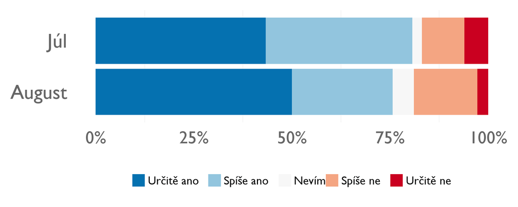

# Srovnání s minulým Discoverem

## Júl

- Organizace se zlepšila a všechno je propracovanější. Na druhou stranu letos nebylo moc času na poznávání ostatních. Jinak si myslím, že se našlo idealní číslo účastníku. Mohly by být dva odpolední worshopy jako v minulých letech.
- Zlepšuje se to každým rokem, nicméně minulý rok byl dobrý v tom, že tam bylo víc mých kamarádů a víc účastníků.
- Nepáčilo sa mi, že bolo tak málo poobedňajších workshopov.
- Je fajn, že je tu méně lidí, na druhou stranu mě mrzí, že lektory, kteří budou na druhém turnusu nepotkám. Taky bych zvážila týmové workshopy.
- Pacilo s ami zavedenie timovzch workshopov a vecernych workshopov, rovnako zlucenie talentmanie do jedneho dna
- Zlepsilo - vecerni program jak se nezblaznit aneb kazda zkusenost dobra. Zhorsilo - tymove workshopy odpoedne.
- večerné workshopy miesto poobedných…
- Je lepsie, ze tu bolo menej ludi ako predtym plus sa mi velmi pacil napad vecernych worshopov.
- Este menej volneho casu akk predtym
- nbola som
- Zlepsila sa praca v timoch, zhorsil sa pravdepodobne cas na volny cas resp. nebolo ho tak ako minuly rok ked napr. nebola vecierka ale unaveni sme ani tak neboli.
- Tezko posoudit, bylo tu min lidi.. A vecerka… A kuracke misto
- menej kamaratov kvoli tomu rozdeleniu na turnusy
- Určitě je lepší, že je tu méně lidí, ačkoli je zároveň smutně, že spousta kamarádů jede na druhý turnus. Pak se zlepšilo moje ubytování, Okály jsou oproti Javorníku středověk. Zlepšila se pevnost Discover, žádné nošení lidí na zádech či jinde, stokrát sláva!
- uvitala jsem funkci psycholozky a vecerni panel, naopak mi vadilo nahrazeni odpolednich workshopu skupinovymi a malo workshopu poezie
- Ešte menej voľného času, žiadna káva, obmedzenie pohybu v okolí, obmendzenie sociálnej menšiny milovníkov čerstvého vzduchu
- Co se zlepšilo a není to v dotazníku: Kvalita tašek Větší písmenka na jmenovkách Co se zhoršilo a není to v dotazníku: Večerka Chybí káva a čaj
- Účastníci, přístup lektorů, témata k diskuzi, hosti - zlepšilo. Hututu - chybělo u metlobalu.
- Prisne pravidla a podla mojho nazoru to sposobilo dost sok medzi ludmi ktori tu uz boli. A lektorsky tim bol dost inej zostavy co mi bolo trochu luto.
- Vytištěný seznam s tagy lektorů a vícekrát oheň. Skvělé změny :)
- viac voěného času viac voľna žiadna večierka viac se mali povolené a bola ĺepšia atmosféra

## August

- Pozitivni: Bylo vice casu na odpocinek a pokec s lektory. Negativni: nic me ted nenapada.
- už som spomínala skôr a ĺuďom individuálne
- Zlepsilo: Za oponou Přežívala sem to i na, lepší, vím Viac info, some moudřejší a tak sem to malá zase jednoduchsie naučit se čím viac Zhorsilo- nemám poznamky
- Akce se vyvýjí, neřekl bych, že se něco zhoršilo. Drží si standard a roste.
- Teamové workshopy byly přínos. Disvoer si drží laťku vysoko od počátku věků.
- Presunuti temovych aktivit pred veceri nebyl nejlepsi napad, minuly rok to bylo lepsi. Spokecne vecere s teamem by mohly nahradit ten dlouhy cas na diskuzi ve spol. Mistnostech apod. Pritomnost psychologa skvele!! Jen bych tu dala alespon jeste jednoho.
- Timove workshopy boli spektakularne
- Lepší : týmové workshopy Horsie: uvodnyprihovor o dodržování pravidiel
- Vetsi focus na dusevni zdravi, lepsi teamove workshopy, mega up (y)
- Chybala mi ta masa ucastnikov.
- Discover bol rozdelený na dva turusy a mne to pripadalo ako zlepšenie, pretože som si teraz vytvorila dôvernejšie vzahy s účasníkmi
- Lepší výber kurzov. Chýbali mi workshopy z oblasti biológia,medicína a tak pod.
- Sú zaujímavejšie workshopy. Určite sa zmenili témy a aj tímové workshopy sú zaujímavejšie.
- Zhorsil sa vyber workshopov, lebo pocas minulych rocnikov bol lepsi vyber - viac wokshopov o studiu v zahranici, o jazykovych certifikatoch,… Zlepsili sa timove aktivity.
- Všetko bolo super, akurát mi chýbal notes, možnosť robiť si kávu / čaj a metlobal
- timove workshopy top!
- Velmi sa mi paci napad s timovymi workshopmi, prednasky o dusevnom zdravi.

# Proč to děláme?

## Júl

- Myslím si, že je to forma předávání zkušeností. Každý z lektorů studoval na prestižní škole a teď chcete předat znalosti dál. Podpořit lidi co mají na studium v zahraničí, aby překonali svůj strach. Další vaše motivace podle mého je měnit českou a slovenskou společnost mimo vracení společnosti vaše úspěchy. Podpora aktivity studentů muže změnit vše od vědy po politiku a vaší záměrem je dát jim možnost poznat ostatní takové studenty a najít svůj potenciál.
- Vykouzlit usmev na tvaři lidem, kteří se chtějí vzdělávat.
- Aby sa aktívni študenti, ktorí sú namotivovaní zlepšovať sa mohli spolu stretnúť a aj porozprávať s lektormi ktorí majú veľa skúseností a zaujímavých tém o čom sa rozprávať.
- Preto, aby sa mladý ľudia vedeli lepšie rozhodnúť akému povolanie sa chcú venovať, po prípade či ich to bude baviť a či to aj psychicky budú zvládať. Ďaľšia možnosť je že sa mladý ľudia niečo nové naučia spoznajú nových ľudí a tý čo nevedia čomu sa chcú v budúcnosti venovať môžu tu nájsť to pravé orechové :)
- lebo to rozvýja mladých študentov a pomáha im vybrat si cestu
- Podľa mojho názoru chcete ukázať mladým ľuďom, že škola a vlastné štúdium nie je jediná možnosť vzdelávania sa.
- Aby jste mohli předávat svoje zkušenosti dalším lidem, a rozvíjeli tak jejich rozhled. Pomáhali s rozhodováním do budoucna (aspoň stručné načrtnutí cesty) a užili si to s námi ;)
- Myslím si, že Discover robíte najme preto, aby ste inšpirovali mladé študenty k ich potenciálom.
- Aby sa mladí ľudia dostali k informáciam a skúsnostiam, ku ktorým by sa bežne nedostali, od výnimočných ľudí, ktorých by bežne nestretli.
- Myslím si, že to děláte pro vzdělání středoškoláků a že jim to pomáhá v budoucím směrování na VŠ.
- Pretoze chcete odovzdavat v nejakej podobe to co ste sami dostali a pomahat menit aa zlepsovat zivoty studentov
- Aby mladí lidé poznali více možností, jak se v životě vzdělávat a byli odhodlaní měnit svět. :-)
- Abyste nam mohli predat sve zkusenosti a motivovat nas
- Aby ste ukázali ľuďom aké možnosti majú a naučiř ich niečo, čo budú v živote potrebovať.
- Aby ste vychovali “elitu” národa - ľudí vzdelaných, s nápadmi a vedúcimi schopnosťami. Tiež vás podľa mňa zaujímajú naše názory.
- Aby ste vychovávali a rozvíjali potencionálne budúce vedúce osobnosti Slovenska.
- proto, aby studenti využili svůj plný potenciál, vzdělali se a dozvěděli se o svých možnostech a protože vás to baví
- Aby ste inšpirovali mladých ľudí a podporili ich v ich cieľoch.
- Pretože to má zmysel, pomáhať nadanaj mládeži a trochu ju nasmerovať, na ceste za úspechom, alebo za tým, po čom túžia.
- Abyste pomohli mladým lidem, kteří se rádi učí novým věcem, přemýšlí a mají zájem na tom se rozvíjet.
- Aby ste mladym ludom ponukli inu moznost vzdelavania a pomohli nam objavit nove moznosti.
- Aby sa mladý ľudia dozvedeli o vsetych možnostiach ,ktore im tento svet prináša. Nieco nove sa naučili,spoznali ľudí ako su oni a taktiež ľudí,ktorý toho v živote už vela dokázali.
- Aby ste študentom ukázali správnu cestu do budúcnosti a umožnili im vyskúšať si, či by ich jednotlivé predmety/odbory bavili.
- Aby sme mohli zažiť najlepší týždeň nášho leta! A to sa Vám naozaj podarilo. Základnými intenciami sú ale veci ako napríklad spoznávanie neskutočne úžasných ľudí, ktorí nám vedia odovzdať mnoho cenného; učenie sa fascinujúcich vecí, o ktorých sa skrátka v škole neučíme či pomoc pri objasňovaní našej budúcnosti.
- Aby ste nam pomohli s vyberom skoly, povolania, cielov.. Niektori z veducich to nemuseli mat lahke kedze im nikto nepovedal ake to bude a myslim si, ze vy nam s tym chcete pomoct.
- Pretoze este stale existuju ludia na Slovensku a v Cesku, ktorych zaujima co sa deje okolo nas a vedia ze sa to da zmenit. Takisto kriticky uvazuju a bazia po novych vedomostiach a zisteni ako mozu byt uzitocni
- Chcete infomovať mláďaž o jej možnostiach , dávate priestor pre osobný rozvoj.
- Myslím si, že preto, aby sa zlepšilo všeobecné povedomie o dobrovoľnom vzdelávaní študentov a aby mali študenti ľahšiu cestu k informáciám.
- Aby ste inšpirovali mladích v nových veciach, podporili ich ich terajších záujmoch a aktivitách.
- Myslím si, že Discover slouží nejen jako stmelovací akce pro lidi, kterým nevadí se učit, zajímají se a bádají, ale také jako prostředek poznání a otevření více možností. Ukázat nám, že nic není nemožné, svést dohromady lidi se stejnými zájmy a podělit se o vše, co může (ale nemusí) v budoucnosti pomoci.
- Podľa mna je jedným z vašich cieľov vychovávať nás, urobiť z nás slušných, etických ľudí, ktorí nie sú sebeckí, a zamýšľajú sa nad všetkým, čo robia (teda okrem toho dobrovoľníctva, keď je niekedy lepšie príliš nad tým nepremýšľať :) )
- Pomahate nam si uvedomit vsetky mozne cesty ktorymi mozeme ist po ukonceni skoly.
- Chcete ukázať mladým ľudom že aj napriek tomu že sú z nejakej malej zapadnutej krajiny, môže dokázať veľa. Môžu ovplyvniť veľa.
- Aby ste motivovali mladých ludi a pomohli šikovnej mládeži dostať sa na vrchol
- Pre upevnenie vztahov medzi mlad. ludmi a pre ich spravnu vychovu aby z nich boli uspesny a uvedomeli ludia
- Protože chcete pomoct se vzdeláním naší generace.
- Letná Akadémia Discover slúži pre ambicióznych stredoškolákov, ktorí by sa chceli dozvedieť viac o niektorých odboroch, spojiť sa s ďalšími ľuďmi s podobnými ambíciami a záujmami, dozvedieť sa veľa o aktuálnych témach a zistiť, čo ich skutočne baví a čomu sa možu v budúcnosti venovať.
- Aby sa šikovný gymnázisti posúvali ďalej.
- Myslím si, že chcete předávat své znalosti a zkušenosti mladším a motivovat je k učení a dělaní něčeho dobrého pro společnost. Také je vidět, že i vás to baví a berete to jako příjemny tyden zábavy.
- Aby ste poskytli možnosť mladým ľuďom byť ambicióznymi a prebudzovali aktivitu u študentov.
- Pretože podporuje rozvoj mladých a aj za týždeň dokáže zmeniť človeku život.
- Abyste motivovali mladé lidi ke studiu a zájmu o jejich okolí.
- Pre sirenie osvety, rovnako ako zdruzivanie ludi s perspektivou do buducnosti, ktory maju zaujem nieco zmenit a nie len pasivne sa prizerat a prezivat vo svete, ktory tolko ponuka.
- Pretože ste úžastní ludia, ktorých zaujíma okolie a chytajú sa každej možnosti niečo zmenit. Ďakujeme!
- Protože vás to do jisté míry baví, protože nás chcete vzdělat, protože chcete šířít mír a lásku.
- Vlastní zájem a dobré srdíčko? :)
- Kvoli mladým ludom, kt. na sebe chcu pracovat aj pocas leta
- Chcete ukázat studentům, jaké možnosti a příležitosti v dnešním světě mají a inspirovat nás svými obvykle velmi netradičními životními příběhy.
- Zdielanie informacii so studentmi, ktore mozu pomahat ich osobnemu rozvoju, ktory je neskor dolezity pri zlepsovani systemu v ktorom zijeme.
- Aby jste lidem napomohli objevit to co by je mohlo bavit studovat do budoucna
- Aby jste pomohli studentum poznat dalsi lidi s podobnymi zajmy jako je napriklad skola a vzdelani obecne a take jim ukazat, jak se mohou rozhodovat do budoucna.
- Aby sme mali na Slovensku a česku viacej vzdelanych ludi, aby ste nas podporili v tom co robime a tiez nas chcete podporiť v tom aby sme sa nebali snívať vo veľkom.
- Aby ste poskytli novy pohlad na veci do buducna a vseobecne pre ludi ako my, ci sa uz nevieme rozhodnut akym smerom ist alebo sa potrebujeme uistit, ci ten smer, ktory sme si vybrali nas bude aj naozaj bavit.
- Aby ludia mohli spoznat sance ktore v zivote maju, popripade by mohli zistit kade sa chcu v zivote vydat
- Aby ste ukazali mladim ludom co vsetko je mozne, ze vzdelavanie moze byt aj zaujimave a maju ovela viac prilezitosti ako si myslia.
- Aby nadejni studenti boli informovani o tom ako si moze zlepsit buducnost
- v CS je kopa sikovnych deciek, ktore pri sebarealizacii potrebuju skusenu pomocnu ruku
- Aby ste nám ukázali, že učenie môže byť zábavné, záživné a hlavne efektívne.
- Aby mladí studenti viděli příklad starších a zkušenějších, protože to jsou inspirativní lidé. Taky na podporu motivace, k povzbuzení naší zvídavosti a kritického myšlení.
- Motivace a vzdľlávání budoucí československé elity.
- Vždy na Discoveri som mala pocit, že lektori tu boli naozaj pre nás a pomáhali nám ako vedeli. Často ukrajovali z vlastného času, aby nám mohli poradiť alebo pomôcť bez toho, že by sme im to mohli momentálne nejak reálne vrátiť. Teda myslím, že to robili kvôli tomu, aby sme boli najlepší ako vieme byť a aby sme mohli meniť aspoň tú trošku, na ktorú budeme mať dosah.
- Prave kvoli tomu dovodu, nasmerovat mladych ludi k svojim cielom a vytuzenym skolam a podat im ovela viac informacii.
- Aby si mladí lidé uvědomili, co chtějí v životě dělat a co je baví. Discover dává středoškolákům mnoho nových možností a snaží se, aby lépe dosáhli svých životních cílů (práce atd)
- Protože vás to baví a chcete predat sve životní zkušenosti druhým.
- Kvůli nedostatkovosti moderních školních systémů. Jako přípravu na VŠ.
- Na ukázanie mladým študentom iné sposoby sebarealizácie, rozšírenie možnosti a rozhľadu a aj socializácia s inými ľudmi a všeobecne aj vzdelávanie.
- Je důležité získávat nějaké vzdělání, ale v určitém bodě je stejně důležité i nějaké vědomosti předat. Hodně z lektorů se sem podle mě vrací proto, že vědí, že svým příběhem mohou ovlivnit rozhodnutí někoho, kdo by, bez Discoveru, mohl skončit úplně jinde, než kde plánuje.
- Myslim si, ze tyto ludia chcu akymsi sposobom vychovat z dalsich generacii inych ludi, ktori sa nebudu bat premyslat a vyjadrit svoje nazori.Lektori podla mna chcu prezentovat svoje skusenosti a postrehy nam a to uzastnou formou. Da to mnoho nam a aj im to doda chut do dalsej prace.
- Aby ste nám pomohli v našom osobnom rozvoji, ukázali cesty, ktoré nevidíme.
- Já se domnívám, že lidé kteří discover tvoří, jsou lidmi, kteří chtějí udělat něčo víc, co není jinak k dispozici. Že je baví pomáhat ostatním v tom se zlepšovat a snažit se, aby bylo co nejvíc lidí, kteří přemýšlí i nad věcmi, u kterých to není tak samozřejmé a že to považují za něco smysluplného, pomocí čeho můžou mladým lidem pomoc posouvat se dál.
- Rozhodne delate Discover, protoze vas bavi a protoze bavi nas. Urcite chcete predat to nejlepsi, co ve vas je, abychom meli jednodusi zivoty v oblasti budoucich studii, ve kterych budeme pokracovat
- Reciprocita, poslanie
- Myslím si, že chcete poukázať na to, aké je lepšie a efektívnejšie vzdelávanie. Taktiež aby študenti využili múdro voľný čas v lete a spoznali nových a zaujímavých ľudí.
- Aby sme my, mladá budúcnosť uvideli, že školy v Anglicku, USA, Európe, sú pre nás dosiahnuteľné. Máme na výber široké spektrum aktivít, vedúcich ku zvýšeniu našich schopností, vedomostí a hodnůt.
- Pomoc studentům s “průzkumem” nových možností, prohloubení zájmu o dané obory
- Protože by jste jako mladí taky uvítali podobnou akci a taky rádi předáváte své zkušenosti jako je někdo předal vám.
- Preto, že chcete aby spoločnosť mala vzdelaných členov, ktorí kriticky rozmýšľajú, sú otvorení novým možnostiam a snažia sa, aby čo najefektívnejšie pomohli spoločnosti a okoliu.
- Ukázanie študentom, ako sa uplatniť v rôznych odvetviach. Možnosti, o ktorých možno nevedeli, riešenia rôznych aktuálnych tém- rozširovanie prehľadu.
- Aby mali mladí ľudia možnosť rozvíjať sa osobnostne a v témach ich záujmu
- aby ste pomohli Česku a Slovensku
- združuje študentov z českej republiky a slovenska, ambicioznych ludi, ktori maju šancu uspiet, ponukate rady a vlastne skusenosti, ktore mnoho z nich nema odkiaľ čerpať.
- Podľa mňa je to odkázanie skúseností či už v oblasti štúdia alebo vzdelania nám, študentom.
- Aby sa pomohlo študentom s ich plánmi do budúcna.
- Aby mladí ľudia so spoločnými záujmami a víziami si mohli vymeniť vedomsti a skúsenostu
- Aby ste dali možnost mladým ludom rozšírit si obzory, dozvediet sa niečo o tom čo ich zaujíma a čo si myslia že chcú íst študovat.
- Ukázat lidem možnosti daného oboru, co obnáší jeho výuka na VŠ a dát příležitost setkat se s podobně smýšlejícími lidmi,
- Chcete pomôcť mladým študentom pomôcť nielen v akademickom ale aj v rozvoji osobnosti každého jedného z nás.
- Abz ste dopomohli mladým rozvíjať sa v smeroch, o ktoré je ťažšie zaujímať sa v škole a zároveň im to bolo podné iným spôsobom ako v škole a ukázali im veľa možností, ,ktoré ako mladí, majú.
- Jako prostředek, kterým se dá zlepšit svět vzděláváním alternativní cestou.
- Aby ste ukazali mladym ludom ich moznosti a zaroven aj skryty potencial ktory mozno sami nevidia.
- Meaningful flow :)
- Prave aby ste nejakym sposobom mohli pomoct mladym studentom ktori nemaju pristup k informaciam ktore vy poskytujete alebo aby ste ukazali mladym ludom akymi vsetkymi smermi sa mozu uberat.
- Víra v to, že Discover a jeho nedílné součásti- šíření povědomí o společenských problémech, podpora občanské angažovanosti… má smysl.
- podat mladym skusenosti, tipy, triky, povzbudit ich k diskusiam nad spolocenskymi problemami¨ zabava networking povzbudit mladym, aby to co sa tu naucia sirili dalej
- aby sme vdeli čo sa dá študovat, čo nam v škole neukážu

## August

- Ten team spirit je tu absolutne neuveritelny - snad vam studenti davaji pocit, ze to, co pro ne delate, dava smysl. Protoze pro ne jste inspiraci, co se vydala cestou, ktera se zdala nedosazitelna. A taky se muzete setkavat mezi sebou, ackoliv se v mnoha pripadech venujete jinym oborum a jste vsude mozne po svete.
- Aby ste dali šancu mladým ľuďom nájsť sa vo svete, motivovať ich. tiež si myslím že vytvárate akýsi network inteligentných ľudí z Čiech a Slovenska
- Snažíte sa inšpirovať mladých ľudí, pomocť im v rozhodovaniach v živote. Veľa krát som sa v živote stretla s nepochopením a zistila som, že veľa ľudí mali podobný problém a tu na Discoveri som sa stretla s veľmi priateľskými a otvorenými ľudmi, čo zdieľali podobné názory, a ak nie, akceptovali ich a neodsudzovali nás kvoli nim, Za to si celú Discover akademiu vážim.
- Myslim, ze chapem, preco toto cele robite prave preto, lebo niecomu podobnemu by som sa chcela v buducnosti venovat aj ja. Podat svoje skusenosti, ukazat mladsim moznosti a pomoct ci nasmerovat ich, je nieco uzasne pre obe strany.
- aby ste pomohli mladym ludom zorientovat sa o tom co by mohli robit a ako to studovat na skvelych univerzitach a mozno ich inspirovat k podobnym aktivitam
- abychom zjistili o cem jednotlive studijni obory jsou a dostali doporuceni na vhodne skoly
- aby ste zvýšili úroveň informovanosti mladých a nádejných ľudí, ktorí sa možno ešte len hľadajú a nevedia čo ďalej
- Určitě pro motivaci studentů a také ukázat jim, kolik mají příležitostí.
- Motivovat studentu Pomoc jim rozhodnout se Zabavit se a současně dozvědět se něco nové při super lidech
- aby ste vylepšili znalosti a osobnosti mladých ľudí
- Máte chuť podpořit mladé lidi + je to super položka do CV. Moc Vám za organizaci Discoveru děkuji!
- Myslim si, ze prave pre to, co som opisala v predoslej otazke o tom, com mi Discover dal. Ak teda je vasim cielom vyhladavat aktivnych mladych ludi, otvorit im nove obzory a motivovat vlastnym pristupom a konanim, skutocne sa vam to podarilo.
- Predstavenie novych moznosti studentom, mimoskolske vzdelavanie a ciastocne usmernovat studentov
- Abyste umoznili abicioznim mladym lidem rozsirit si obzory, nechat se inspirovat uspesnymi lidmi.
- Myslim, ze se jedna o projekt, ktery pomaha mladym lidem rozvijet sam sebe, pomahat v royvoji v oblasti budoucnosti a nasledovneho postupu v zivote, mne osobne pozitivne ovlivnila a urcite i ovlivnovat nadale bude v oblasti dusevniho zdravi. Smzslem tohoto projektu je rozsireni obzoru, poznani spousty novych lidi, kteri se zajimaji o stejne veci a maji stejne konicky. Cely projekt hodnotim velmi kladne.
- Abyste rozsirili obzory mladych lidi, dali jim prilezitost vyzkouset nove veci a ukazali, ze vzdelavani muze vypadat i jinak nez na skolach.
- Aby ste nabudili mladých ľudí dychtivých po vzdelaní , otvorili im možnosti, ukázali učenie z inej stránky a celkovo ich inšpirovali.
- Protože vidíte vyšší cíle, než jen “hrabání si pro sebe”. Chcete předat určitou část svých znalostí ostatním a domnívám se, že vám to dělá radost. Spíš vás to určitě těší, vzhledem k vašemu nadšení pro věc. Možná se i rádi setkáváte s novými názory a chcete poznat studenty a ukázat jim v životě směr, kterým by se mohli vydat.
- Umožniť mladým ludom, ktorým nie je ich buducnosť lahostajna, aby sa dozvedeli o roznych možnostich a sposoboch, ako svoje tuzby v zivote zrealizovat a využiť svoj potencial.
- Myslim ze chcete sirit to co jste meli moznost zazit studovat a tak a zkratka to chcete predat. To dobre chapu protoze mam takove nutkani taky. Vam se to ale povedlo na suprove urovni. Jste uzasni
- Aby ste pomahali stredoskolakom na ceste za karierou a aby ste zlepsovali spolocnost
- Chcete předávat dál svoje zkušenosti a znalosti :D
- Minuly rok jste rikali neco ve smyslu, ze Discover je akce, kterou byste si prali jako lide v nasem veku,
- pretoze vela lektorov chce odovzdat svoje informacie a vedomosti dalej , potencialnym dospelym ludom uspesnych v spolocnosti, chcu nas naucit co je dobre a co zle , ako sa spravne rozhodovat, najst motivaciu a dosihanut svoj ciel a oni su pre nas velkym vzorom.
- Aby jste mladým lidem ukázali že vzdělání se neomezuje jen na školu a především že jde ucit jinak.
- Ukázat mladým lidem možnou cestu, kterou se muže jejich život ubírat, pomocí zajímavých kurzu, lektoru, prostředí atd. Dále také spojit studenty s podobnými zájmy a plány do budoucna.
- Aby ste inspirovali mladých ľudí, obzvlášř tých, ktorý sú aktívni a snaživý
- edukacia mladych ambicioznych ludi
- Aby stě ukázali nové možnosti a motivováni a přitom kladli doraz na duševně zdravím a věci co se právě dějů okolo nas
- kvuli spojovani lidi se stejnymi zajmy a ambicemi
- aby ste posunuli nas mladych ludi dalej, aby ste nam ukazali ze su moznosti a mame na ne aby se dbali na spolocnost a zlepsoval to pomahal ostatnym a nerobili zo seba sebecku :elitu:
- Myslim si, ze robite tuto uzastnu akademiu pretoze viete, ako to moze mladeho cloveka ovplzvnit a posunut smerom dopredu.
- Aby ste edukovali talentovaných mladých ludí nielen nad rámec učiva ale aj obznámyli ich o možnostiach ktoré sa im naskytujú.
- Pretože viete, že vychovávať ďalšiu generáciu má zmysel, že sú ľudia, ktorí chcú vedieť, nadchnúť sa, pretože vy patríte tiež medzi nich
- Protoze se snazite predat svoje znalosti a zkusenosti predat druhym, predat jim svuj odkaz, pomoci jim vyvarovat se vasich chyb. Sdruzit talentovane mlade lidi.
- Protoze chcete predat nejake sve znalosti a knowhow (nejen oborove, ale i treba o studiu v zahranici, dusevnim zdravi, atd…). Doufam, ze se k vam jednou pridam.
- Jako pomoc maldým lidem. Ať už pomoc k rozvoji jejich znalostí nebo i naplánování jejich budoucí potencionální kariéry.
- Myslím si, že patríte medzi ľudí, ktorí si uvedomujú aké to pre nás v tomto veku je. Na čo asi myslíme a aké otázky si kladieme. A ste tí, ktorí si prešli niečim podobným a preto nám dokážete pomocť a poradiť či už s výberom školy alebo čímkoľvek iným.
- Podelit sa o vedomosti a skusenostami
- Preto, aby sa mladi ludia dozvedeli o moznostiach, ktore su realne a ukazat ostatnym, ze dostat sa aj na taky Harvard nie je nedosiahnutelne.
- Aby ste zblížili ľudí s rôznymi záujmami a ukázai im príležitosti.
- Aby ste pomohli mladým a zároveň odovzdali svoje skúsennosti a tým pomohli budovať lešiu budúcnosť Česka a Slovenska
- Vzbudiť záujem a motivovať študentov.
- Protože máte k vědění vášeň a chcete ji sdílet s ostatními, vzbudit/podporovat v mladých lidech zvědavost a ukázat jim růzé možné cesty budoucím studiem a životem?
- Protože jste skupina nadšených lidí, kteří si uvědomují, že mít životní informace od lidí, kteří studují super školy, je pro člověka hrozně důležité a mohou mu leckdy pomoci.
- Umoznujete stredoskolskym studentum nahlednout a vyzkouset si ruzne obory, ktere by mohli studovat v budoucnu. Muzete jim tak pomoct objevit, co je zajima a bavi. Navic je muzete inspirovat a ukazat jim, jake moznosti studia existuji, at uz u nas nebo na zahranicnich univerzitach.
- Protoze chcete sdruzovat studenty a “donutit” je premyslet na necim nad cim se normalne napr. ve skole vubec neuvazuje. Myslim, ze vasim zamerem je mladym lidem rozsirovat obzory a motivovat je do budoucna.
- Chcete pomôcť mladým ľuďom, ktorí sú uvedomelí nájsť svoj smer, odbor, naviesť ich na ten správny chodníček a podeliť sa s vlastnými skúsenosťami.
- Aby si žáci uvědomili, ze mají obrovské spektrem moznosti
- Baví vás to.
- Aby sa mohli študenti dozvedieť viac o veciach, ktoré ich bavia a zaujímajú, a nevedia sa k ním dostať v škole. Aby ste nám pomohli získať rozhľad a aj preto, aby ste nabudili náš záujem o budúcnosť a ľudí okolo nás.
- Aby ste ukazali ziakom, ake maju moznosti a pomohli im zistit, co chcu v zivote studovat a robit.
- Aby ste pomáhali mladým a zároveň im posunuli svoje znalosti a skúsennosti a pomohli spraviť lepšiu budúcnosť pre Česko a Slovensko
- pretoze sme buducnost a my sme ti ktori mozu zmenit tento svet, preto je dolezite aby sme sa ucili kritickemu zmyslanu, dorym moralnym prncipom a inym veciam uz od mladeho veku kedy nasi rovesnici riesia ine veci ako uprchlicku krizu
- Ukázat nové možnosti študentom a podat svoje skúsenosti ďalej,
- Předání zkušeností. Snaha vést mladé lidi, ukázat jim jiné pohledy a směry do života.
- Aby ste pomohli studentom vo vzdelavani sa
- Preto aby sste spajali lidi a oboznamovali ich s novými moznostami.
- Aby ste sa podelili o svoje vedomosti.
- Presne pre to, čo som napísal v predchádzajúcej odpovedi. Cieľom je motivovať študentov a určite aj lektorov na zmenu. Tak ako bolo na Eliškinom workshope spomenuté, že stačí len chcieť a zmena sa dá zvládnuť.
- Priestor pre nás, aby sme sa stretávali s ďalšími super ľuďmi a lektormi, ktorí môžu byť pre nás ďalší rozvoj obrovskou inšpiráciou.
- Pro zlepseni povedomi o jinych projektech, pro jiny pohled na svet ucastnikum a v neposledni rade motivovat k dalsimu vzdelani.
- Aby ste mladym zvacsovli obzory a aby sa mohli zaujimat o veci ktore ich bavia ale v skole na nich nie je dostatok casu
- Myslím, že chcete mladým ukázat možnosti a přednést zkušenosti. Otevřít pro nás nové dveře, které jsme před tím ani neviděli :)
- Aby ste rozšírili obzor mladým šikovným študentom, aby ste im pomohli ukázať čo všetko môžu robiť a áno to môžu robiť… Obozbamujete študentov s možnosťami o kt.ani len netušili
- Smyslem je podle me ukázat studentum, že i škola je zábavná, navázat nové kontakty, poznat super lidi, sdílet príležitosti.
- Příležitost pro ty, kteří o ni stojí
- Máte chuť motivovat mladé lidi.
- Myslim si, ze chcete otvarat moznosti studentom, ktori zatial nevedia, co chcu studovat, chcu vyuzivat svoj cas efektivne, dozvediet sa neico nove. Taktiez si myslim, ze cielom Discoveru je ukazat studentom, kam az mozu siahat a nebat sa dosiahnut svoje ciele.
- Jednou úžasnou vecou je ze sa cely týden mozme zaoberat tým co nás baví a to co by sme chceli v budoucnosti robit. Mozme sa porozpravat s lektořmi ktori studuji to co zaujímá nás a spytat sa ich na vsetko od prijimacky na vysoku až po výhody a nevýhody tento práce. Taktéž preto aby sa mladí ludia začali viac zaujímal o svoje okolie a nebolí k němu lahostajni. Tiez tu člověk spozna ludi ktori ho osobnostní posunu dal.
- pretože podporovat mladych ludi je dolezite a ma zmysel
- Aby ste pomáhali mladým ľudom nájsť sa v nejakom odbore ale tiež aj aby ste ich motivovali svojimi osobnými príbehmi
- Aby mali inteligentný mladí ľudia cez leto miesto alebo čas sa stretnúť s niekym, kto je im podobný. Taktiež aby ste mohli posunúť vaše skúsenosti nám.
- Myslim, ze hlavny dovod je, ze sa snazite odovzdat a podelit sa so svojim doterajsimi skills a vidite v kazdom jednom z nas velky potencial.
- Kvůli snaze o něco zlepšit život studentů a rozšířit povědomí o tom, jak se můžeme dále vzdělávat a doplnit některé mezery, o kterých bychom měli vědět.
- Setkání mladých lidí s lidmi z oboru a se sebou navzájem, nové infomrace a nový úhel pohledu, zkrátka zlepšit svet
- aby inspirovali mladich ludi
- Chcete neco vratit zpatky domu
- Pre pomahanie mladim ludom najst a venovat sa tomu, co ich bavi.
- Protože vám záleží na studentech a jejich budoucnosti
- -otvorenie sveta mladým ludom ci uz v oblasti vzdelavania, moznosti alebo kontaktov + vedenie k spravnym hodnotam
- Jednak preto aby sme zistili co nas bavi. Je to tiez skvela prilezitost porozpravat sa s ludmi ktorí studuju to co by sme chceli a zistit vestko o tom odbore ako aj o jeho studiu. Taktiež preto aby mladi ludia neboli lahostajni k svojmu okoliu a ludom v nom.

# Co by vzkázali budoucím účastníkům?

Ptali jsme se jen na júlovém turnusu.

- Jednoduše aby se přihlásili. Změní vám to život.
- Určitě to zkuste.
- Určite sa zúčastine, dá vam to veľmi veľa, nie len stretnete veľa zaujímavých ľudí, ktorí majú podobné záujm ako vy, ale aj veľa zaujímavých lektorov, ktorí vám možu veľa poradiť čo robit po strednej, kde ísť študovať….
- Je to tady super, a najdeš tu spoustu spřízněných duší.
- Poďte do toho.
- Choďte na co nejvíce workshopů. Dospat se můžete jindy.
- Že je to skvělá akce, která rozhodně stojí za to.
- Urcite bych ho doporucila
- Určite sa zapojte získate veěa nových skúseností.
- Naplno strávený týždeň! :)
- poznáš mnoho velmi přemýšlivých a milých lidí
- Že sa majú pripraviť na veľa pozitívnych myšlienok.
- Je to naozaj najlepší týdeň leta a beriem si z stadialto jedny z najkrajších spomienok
- Týden, který mi změnil život. Mnoho a mnoho přínosných informací. Změnila jsem pohled na svět. Určitě jeďte!
- Je to super, dozviete sa vela novych veci, spoznate vela novych skvelych ludi, urco podte!
- Aby sa určite zúčastnili, pretože je to nezabudnuteľná skúsenosť.
- Že je to úžasný zážitok a veľmiobohacujúca skúsenosť. Neváhajte!
- Super!!! Urcite chodte!
- Jednoznacne odporucila. Je to uplne uzasny tyzden
- Je to super príležitosť dozvedieť sa o svojich možnostiach, spoznať nových ľudí a mať zábavu.
- Stojí to za to! Určite sem príďte!
- Nečakaj a prihlás sa! Stojí to za to.
- I po přečtení brožurky je to celé trošku jiný svět, takový výběr do Bradavic, nikdy nevíš co Tě čeká, co Tě zaujme a koho potkáš.
- Nech sa rozhodne idú pozrieť, je to super skúsenosť
- Neboj sa prihlásiť a choď do toho!
- Ať se ničeho nebojí a rozhodně jedou, je to užasný týden, který si užijí naplno. Je tu plno inspirativních a přátelských lidí, nové vědomosti a zkušenosti, které jinde nezískají. A ať jedou co nejdřívě to jde, protože pro mě je to bohužel poprvé a naposledy. Velmi lituju toho, že jsem se o Discoveru nedozvěděla dřív, určitě by mě to více ovlivnilo jak moje vysokoškolské tak středoškolské studium.
- Že to pravdepodobne naozaj bude najlepší týždeň ich leta
- Určite vyskúšať.
- Určite prídte! Je to velká príležitost a skvelá skúsenost. Odporúčam každému. Nudit sa rozhodne nebudete.
- Je to super.
- Slíbili nejlepší týden mého léta a doručili
- určitě to zkuste, i kdyby ne kvůli kurzům, tak tu minimálně potkáta spoustu skvělých a inspirativích idi (jo, zní to jako klišé, ale překvapilo mě, že to tak fakt je)
- Discover je tyzden na ktorom objavis nielen mnoho uzitocnych poznatkov o veciach ktore nas zaujimaju, ale objavis aj sam seba a co realne chces robit so svojim zivotom ako pocas strednej skoly, tak aj vysokej. To je vec, ktora je v dnesnej dobe skor raritou na taboroch a pritom je tak dolezita.
- Ze by urcite meli prijet ze je to motivuje na studium do budoucna
- Vysvetlila im to co sme tM robili a dúfala ze aj oni sami z toho co im poviem usúdi že je to super.
- Nenechte si ujít jedinečnou možnost seznámit se s kupou zajímavých lidí a věcí.
- Že to majú vyskúšat a uvidia sami čo ich baví.
- Počuvajte, pytajte sa a pracujte na sebe. Discover vam mozno zmeni dalsie posobenie v zivote tak ako mne a vyrazne pozitivne vas ovplivni.
- Ať určite jedou, že jim to da spousty nových informací, kamarádu a že je to opravdu nejlepší týden celého léta.
- Musíte si to zkusit.
- Zábava, hry, interaktivita, nové zážitky, priateľstvá, nezabudnuteľné momenty.
- Aby neváhali, rozhodně nestráví týden školy navíc!
- Discover otvara oci vsetkym, ktory chcu a neboja sa zabojovat vo svete. Uzastna skusenost.
- Nevahejte, ku**a, a pojdte na Discover, budete to tady milovat.
- Discover je super. Dozvieš sa veľa nových vecí a spoznáš mnoho zaujímavých ľudí.
- Je to uzasne a ukaze vam toho tolik, ze na konci tydne nevite, co s tim vsim!
- Je to super, možná ani nemusíte mít zájem o vysokou, přesto je to úžasné prostředí s nejzajímavějšími lidmi a informacemi.
- Je to jedinečná príležitosť zoznámiť sa so zaujímavými ľuďmi a dozvedieť sa kopec zaujímavých informácii.
- Využi túto možnosť, ak môžeš. Naplno.
- Je to jedinečná možnosť zistiť viac a stretnúť ľudí s podobnými či úplne odlišnými záujmami
- nenahraditelny tyzden, nebudu lutovat
- Užite si to ako len môžete !
- Najlepší týždeň mojho leta!
- Že je to tábor , ktorý im dá veľmi veľa. Od nových vedomostí a zručností po nových kamarátov a zážitky.
- Fajn zkušenost
- Urcite sem pridte, je to tu skvele!
- Hodně - záleží, s kým budu konkrétně mluit, protože každý slyší na něco jiného, nicméně že jde poznají reálné vzdělání, posunou se v tom, co mjí rádi, hodně kupředu a lidi zdejsou přátelští, otevření a hrozně fajn.
- Uzite si to tu a vytazte z toho maximum!!!!
- Proč si ještě zdržuješ čtením této věty? Běž se přihlásit! :)

# Co se jinam nevešlo

## Júl

- Lektori sa trochu izolovali a bolo ich tažké odchytiť a porozprávať sa s nimi.
- Bylo to super ;) Děkuju, a snad příští rok :)
- Nelíbila se mi Talent show. Jednak jsem měl problém s bodováním, jednak s Luckou Černou. Bodování vystoupení, která jsou neporovnatelná mi přijde nespravedlivé už z podstaty věci. Jedni měli více humoru, jiní frašky, jiní dramatu, ale každý měl jiný základ. Proto to považuji za nespravedlivé a demotivující. Uvítal bych soutěž bez bodů. A Lucii Bílou znám osobně a nelíbilo se mi, že jste ji takto parafrázovali, protože je příjemná a milá. To vám nezazlívám, ale mrzelo mě to.
- Děkuji moc všem lektorům a organizátorům za ochotu a pomoc. Týden mě velmi ovlivnil a moc doufám, že se Discoveru budu moct zúčastnit i v budoucnu. Děkuji! :-)
- Chtela bych moc podekovat vsem lektorum a organizacnimu tymu za uzasny discover, bylo to skvele!
- Všetci boli super !!!
- všetko bolo fajn-
- dotazník byl příliš dlouhý a detailní, nepamatuji si například na každou hodinu kurzů, myslím, že příslušná otázka neposkytne kvalitní zpětnou vazbu, jelikož jsem vzcházel z mého celkového dojmu, myslím, že otázek by mělo být méně, aby se student nad všemi opravdu mohl zamyslet a některé jenom nezaškrtával podle nahodilého pocitu spíše než hluboké reflexe ačkoliv byli všichni studenti velmi milí a přístupní, kurz mě nijak nemotivoval se se všemi bavit, myslím, že týmy pro týmové workshopy by měli být jiné každý den, rád bych více poznal i jiné lidi mimo své kurzy
- Iba sa chcem neskutočne poďakovať za úplne všetko. Bolo to neskutočné! Len tak ľahko nezabudnem. Ste geniálni ľudia a stali ste sa mojimi vzormi. Prosím, pokračujte v tom, čo robíte, lebo je to viac než úžasné. Už asi ani nemám slov. STE TOP :* (a prepáčte za prípadné gramatické chyby, som unavený z prebdenej noci a rannej turistiky :D )
- Tesim sa na buduci rok ak ma primete :)
- Dakujem vsetkym lektorom, organizatorom a vsrtkym ktori mi zase raz prispeli k mojmu najlepsiemu tyzdnh leta. Odviedli ste kus roboty a som vdacna za vasu ochotu podielat sa na tom. Verim ze disvover bude nadalej tak uzasny pretoze pomaha ludom byt lepsimi.
- Moc oceňuji práci všech lektorů je až neuvěřitelné co jste vytvořili! A samozřejmě děkuju Alex za celý Discover a za její rady, i když mě to mrzí doufám, že příští rok budu v Nepálu v dětské školce, ale této skutečnosti, že mi někdo ukázal, že to opravdu jde vděčím právě Alex a celému Discoveru, tak i když virtuálně, bych chtěla poděkovat!
- Discover sa mi velmi pacil. Je to vazne skvely tabor len mi trochu vadilo ked prisile ten dalsi tabor a nemohla som sa v klude naranajkovat.
- Chce to kávu. A ste úžasný. Som veľmi rada že som tu mohla byť. Ospravedlnujem sa človeku čo to číta po mne, polka textu sa mi rozmazávala pred očami /ehm…výlet na skalu bol faaaajn :D/
- Měla bych opravdu zájem se jakkoli podílet na organizaci Discoveru, protože se ho bohužel už nemůžu jet jako učastník. Discover byl pro mě opravdu jak popisek hlásá - nejlepší týden mého léta a ráda bych ho zažila ještě jednou.
- Ocenil bych více workshopů, které nejsou o studiu/práci/kariéře. Také by mi přišlo lepší, kdyby bylo méně týmů. Stávajících jedenáct je prostě příliš mnoho na to, aby se v nich člověk orientoval. Díky tomu by bylo v týmu o něco víc lidí a měli bychom tak příležitost poznat se s více studenty. Týmové soutěže by mohly být bodovány podle umístění a na konci Discoveru by se vyhlásil vítěz na základě všech souteží. Ale to je spíš taková drobnost, vím, že jde jen o doplněk kurzů a workshopů.
- Snad je velké: Děkuji!
- Ďakujem za všetko! Naozaj.
- velke vdaka Alex a vsetkym organizatorm, odviedli obrovsky kus prace a bolo to super
- Hrozně moc děkuji všem organizátorům v čele s Alex za ten kopec času, který v tom utopili a za všechnu práci, kterou si s tím dali. Jsem moc vděčná, že jsem se něčeho takového mohla zúčastnit, což jsem mohla také díky slevě na poplatku, za který taky moc děkuju! Je mi líto, že to je můj poslední ročník, ale Discoveru i všem Discoverákům přeju mnoho štěstí! =)
- Dakujem vsetkym vam lektorom za jeden nezabudnutelny tyzden. Budem z neho dlho, dlho cerpat.
- Diky moc!
- Večery literatúry sú nezabudnuteľné…
- Uzasne! Diky moc vsem, zvlast Alex
- Udělejte prosím odlišitelné tašky
- v rámci poobednajšieho freetime navrhujem vychádzky s lektorom do obchodu v dedine. Študenti bz si mohli nakúpiť veci alebo s alen tak prejsť
- skveli lektori, naozaj vsetci ochotni, laskavi a mili, taktiez organizatori, obrovska vdaka Alex za cely discover, rozhodne sme si kazdy odniesli nenahraditelne informacie … VELKE DAKUJEM vsetkym a vratim sa aj buduci rok … :D
- Na záver ma celkom sklamalo odmenovanie ,,najlepších" študentov jednotlivých kurzov, vzhěadom na to, že Discover nemal byt o týžden školy naviac, kde nás hodnotia (aké sú vlastne kritéria na toto hodnotenie?( , no mali sme sa prihlásit na kurzy ktoré nás niečim zaujali poprípade uvažujeme nad ich štúdiom v budúcnosti, čiže nevidím zmysel v určovaní ,,najlepšieho" študenta kurzov. Peniaze vyhodené do cien by sa dali omnoho lepšie využit.
- Asi by som chcela poďakovať za štipendium, keďže by som sa pravdepodobne nemohla zúčastniť Discoveru bez neho. Ale zároveň mi nepríde darovanie knižky ako dobrý nápad - rozbíja to novovytvorený kolektív a ničí atmosféru.
- Udělejte společenský večer
- Velmi dakujem vsetkym organizatorom, lektorom, prefektom a vsetkym, tkroi boli nejak zapojeni do discover-u za vsetko usilie, za to, ze sme si mohli uzit nadherny tyzden plny zazitkov, smiechu, radosti, motivacie, inspiracie, ludi s dobrym srdieckom a carovneho prostredia. Dakujem! (napisala by som to aj na dlhsie, lebo si to vsetci fakt zasluzite, no uz musim bezat!) Dakujem, ze som mala moznost Vas stretnut! :)
- Děkuji Alex za všechnu prácii na Discoveru, i ostatním samozřejmě. Děkuji, že čtete a vyslyšujete naše nářeky na zdi. Že přidáváte různé malé zlepšováky jako profily lektorů a org týmu nebo nástěnky, kde co je a fotky lektorů. Je to tu boží!
- DAKUJEM mozno by bolo fajn, keby to bolo dlhsie- pocet dni, aby sa toho stihlo viac a aby bolo viac volna a sportovych aktivit
- nech sa prihlasuju ludia pohla toho či su ranne vtacata alebo radsej idu neskoro spat a podla toho nech su izby, takto sa aj tak nezoznamime lebo nie sme hore v tu istu dobu

## August

- Nebylo by fajn, kdyby jste se vice venovali i sobe? Vidim, ze vas to takhle bavi, ale mam dojem, ze na sebe nemate cas. Treba kdyz by lektori meli kurzy v ruznou dobu a bylo tim padem prilezitostne vice lektoru na jedne hodine, tak to bylo vyborne osvezeni a dalsi pohled na vec. Ale chapu, ze na organizaci by to byo o to vice zabijacke. A libi se mi vice lidskosti na celem Discoveru. Mozna to bude poctem ucastniku, mozna psycholozkou, mozna sdilenim za oponou, ale funguje to. Diky za vse!
- prosím, ak sa vám v tomto dotazníku niečo nebude zdať, pripomínam, že som ho písala v boji so spánkom a s veľmi spomalenou hlavou. I did not mean anything odd. Discover je super. Ste super.Dobrú noc.
- Bylo by dobre pripravit aktivity, pri kterych bychom dostali prilezitost seznamit se s lidmi, kteri nejsou na nasich kurzech, ani v tymu.
- Moc děkuju za tuhle příležitost. Bylo to moc fajn!
- Jsem velmi ráda, že jsem tu mohla být a strávit krásný čas se super lidmi ☺ Dušan, že mi to vyjde a budem moct příští tu další roky akorát organizátora, pomocníka či ne skoro lektorka ☺ Mám Vas ráda.
- Dakujem za vsetko.
- Diky, ze jsem mohla prijet!
- Miluju vas
- Boli ste super a patri vam velke dakujem
- Bylo by zajimave zahrat si nejakou tymovou hru ve ktere by clovek mohl vyuzit poznatky z kurzu a workshopu
- je mi luto Jana a jeho worshopu ako presvedcit kedze tam malo toho duheho pana velmi to stratilo popularitu, skuste sa tomu nabuduce vyhnut :\
- MOhli by ste n budúci rok zorganizovať bitku pomocou vodnych pistoli
- Bylo to nadocekavani uzasne a moc me mrzi, ze uz si to nezopakuju…
- Ty kjáááávo, to bylo něco, tenhle dotazník.
- Nejlepší týden mojeho léta.
- Všechno jsem již řekla na feedbacku s týmem, nerada vyplňuji hodinové dotazníky. Sorry :)
- Díky za vaši energii a čas a trpělivost a nadšení a nápady!! Je mi líto, že jsem tu nebyla ty roky předtím a že už tu příští rok nebudu moct být.. O Discoveru ráda povím co nejvíce lidem a budu na to vzpomínat :)
- nabity program a volitelnost programu, vstricnost lektoru, ferovost organizacniho tymu byly super
- Mockrat vam dekuju, jela jsem sem s mnoha obavami, ale nakonec to bylo hrozne super a hlavne vas lektory obdivuju, ze jste s nama meli tu trpelivost, i kdyz jste se nemohli v podstate ani v klidu naobedvat :)
- Lidi, nechodte bosi, je to nebezpečné!! :D
- Dakujem, že som sem mohla prísť. Bol to najlepší týždeň môjho leta.
- Robte kratsie dotazniky, dostanete kvalitnejsi feedback, lebo ludia bud5u jochotni viac sa rozpisovat
- Ďakujem za úžasný týždeň!!!
- Ucastnici vacsinou nevedia vela o druhych ucastnikoch. Na zaciatku Discoveru by mohli dostat ucastnici aj brozurku “tagov” ostatnych Discoverakov - brozurka s menami a tagmi Discoverakov. Tagy by sa od Discoverakov mohli ziskat pri vyplnani prihlasky a tato brozurka by pomohla najst Discoverakom na Discoveri ludi ktori maju podobne zaujmy (vdaka tagom) alebo sa chcu porozpravat s clovekom ktory ma rovnake zaujmy.
- Všechno tu bylo hrozně super, nejĺešˇ tylden léta (nemůžu se rozpsat, spěchám na bus :D ) bylo to super!!!
- discover byl super v tom, že jsem mohla poznat oxbridge lidi, co by se mi jinde nepovedlo a dívala bych se na studium v UK asi trochu jinak. další báječná vec je ochota všech učastníku a lektoru sdílet své zkušenosti a rady.
- bylo to tu supr, velmi moc děkuji všem a vážím si toho :)
- Ste super, nemente sa lebo robite super veci pre mladych ludi a aj tym robime tento svet krajsim miestom!
- Discover rocks! :)
- Bylo to super a velmi se mi to “páčilo”. Jsem rád za ten týden, co jsme tu spolu strávili :) Děkuju moc za možnost a přijetí! Mějte se pěkně a doufám, že to půjde i tak nadále a i lépe!

Odsud i z jiných otázek:

- několik účastníků přečetlo a ocenilo brožuru lektorů, dost lidí ocenilo nástěnku s lektory
- sem tam se objevil stesk, že se lektoři moc bavili mezi sebou a málo se studenty
- … a jeden student měl naopak obavu, že nemáme čas sami na sebe…
- obecně chuť poznávat účastníky mimo kurz a tým (poptávka po volném čase není jen na reflexi, klid, sport nebo bavení se s kamaráty, ale i poznávání ostatních)
- odpor vůči knižním cenám
- jeden silný principelní protest proti ztvárnění Lucky Černé :-)